# Problem Set #5

David Bacsik

6/4/2018

```r
# packages
library(ggplot2)
```

## Problem Set #5

### Due: Thursday, June 7th

### Problem #1 HELP

Partitioning total variation.

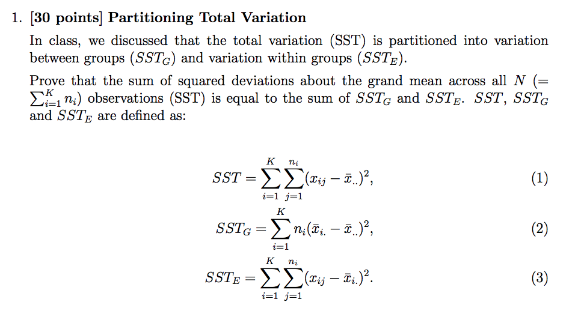

### Problem #2

Complete the ANOVA table above from the values given. The sample size is N = 20.

| Source of Variation | Sum of Squares | df | Mean Square | F |
| --- | --- | --- | --- | --- |
| Group | 56.7 |  |  |  |
| Error |  | 14 | 13.5 |  |
| Total |  |  |  |  |

Since N = 20, and N-k = 14, k must equal 6.

I can then calculate the df for each line.  
Then, I can calculate the sum of squares or mean squares, respectively, for each line using the given information and df.  
The total sum of squares will be equal to SS(G)+SS(E).

Finally, I will find the F statistic as MS(G) divided by MS(E).

Results:

| Source of Variation | Sum of Squares | df | Mean Square | F |
| --- | --- | --- | --- | --- |
| Group | 56.7 | 5 | 11.34 | 0.84 |
| Error | 189 | 14 | 13.5 |  |
| Total | 245.7 | 19 |  |  |

### Problem #3

Complete the two-way ANOVA table for the example problem we discussed in class. The data table is on slide 18 of lecture note 19.

Data:

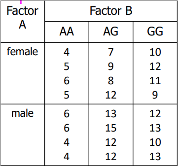

Processing:

| Source of Variation | Sum of Squares | df | Mean Square | F |
| --- | --- | --- | --- | --- |
| Gender | 20.167 | 1 | 20.167 | 9.811 |
| Genotype | 200.333 | 2 | 100.167 | 48.730 |
| Gender-Genotype | 16.333 | 2 | 8.167 | 3.973 |
| Error | 37 | 18 | 2.056 |  |
| Total | 273.833 | 23 |  |  |

### Problem #4

**In this exercise, we will examine the influence of the stress reduction method and age on the stress level. The dataset contains a hypothetical sample of 27 participants who are divided into three stress reduction treatment groups (mental, physical, and medical) and three age groups (young, mid, and old). The stress reduction values are represented on a scale that ranges from 0 to 10. This dataset can be conceptualized as a comparison between three stress treatment programs – one using mental methods, one using physical training, and one using medication – across three age groups. The stress reduction values represent how effective the treatment programs were at reducing participant’s stress levels, with higher numbers indicating higher effectiveness.**

```r
stress_data = read.table(file="http://www.cs.washington.edu/homes/suinlee/genome560/data/stress_reduction.txt")
stress_data = stress_data[,2:4]
colnames(stress_data) = c('method','age','score')
head(stress_data)
```

```
##   method   age score
## 1 mental young    10
## 2 mental young     9
## 3 mental young     8
## 4 mental   mid     7
## 5 mental   mid     6
## 6 mental   mid     5
```

#### #4 a

**We learned that we need to first test whether there is a significant interaction between the factors. Is there an interaction between the treatment and age (i.e., p-value< 0.05)? What is the p-value of the interaction term? If you think that there is an interaction, solve part (b) and (c). Otherwise, solve part (d) and (e).**

```r
m1 = lm(score ~ age*method, data=stress_data)
anova(m1)
```

```
## Analysis of Variance Table
##
## Response: score
##            Df Sum Sq Mean Sq F value   Pr(>F)
## age         2    162      81      81    1e-09 ***
## method      2     18       9       9 0.001953 **
## age:method  4      0       0       0 1.000000
## Residuals  18     18       1
## ---
## Signif. codes:  0 '***' 0.001 '**' 0.01 '*' 0.05 '.' 0.1 ' ' 1
```

I do not believe there is an interaction between age and treatment. The p-value for the interaction term in the ANOVA table is 1. I will solve parts (d) and (e).

#### #4 d

**If an interaction is not significant, we can then test for significance of the main effects separately, again using an one-way ANOVA. Report the result of an one-way ANOVA by copying and pasting the relevant parts of the results. What are the p-values?**

I will run two one-way ANOVA tests, one on each factor. This will tell me the effect of changing that factor, while holding the other factor constant.

```r
m2 = lm(score ~ age, data=stress_data)
anova(m2)
```

```
## Analysis of Variance Table
##
## Response: score
##           Df Sum Sq Mean Sq F value    Pr(>F)
## age        2    162    81.0      54 1.305e-09 ***
## Residuals 24     36     1.5
## ---
## Signif. codes:  0 '***' 0.001 '**' 0.01 '*' 0.05 '.' 0.1 ' ' 1
```

For age, the p-value is 1.3e-9. This is highly significant.

```r
m3 = lm(score ~ method, data=stress_data)
anova(m3)
```

```
## Analysis of Variance Table
##
## Response: score
##           Df Sum Sq Mean Sq F value Pr(>F)
## method     2     18     9.0     1.2 0.3186
## Residuals 24    180     7.5
```

For treatment, the p-value is 0.3186. This is not significant.

From this, I conclude that there is a main effect driven by age, but not a main effect driven by treatment.

#### #4 e

**There are 3 levels in each factor. We learned that when there are more than two levels, we can better understand the mean differences among the levels, through pairwise comparisons of the levels. For the factor(s) that has a significant main effect (i.e., p-value < 0.05), perform three separate one-way ANOVA for three pairs of levels, for example, a ‘young’ and ’mid’ pair, a ’mid’ and ’old’ pair, and a ’young’ and ’old’ pair.**

Based on the results in part (a) and (d), I have concluded that only the age factor has a significant effect. I will subset the data into pairs of levels (e.g. young+mid, mid+old, old+young), plot them, and perform ANOVA tests for each.

For the young + mid age group pair, the ANOVA was highly significant with a p-value of 8.8e-5. There is clearly a better response in the young group than in the mid group.

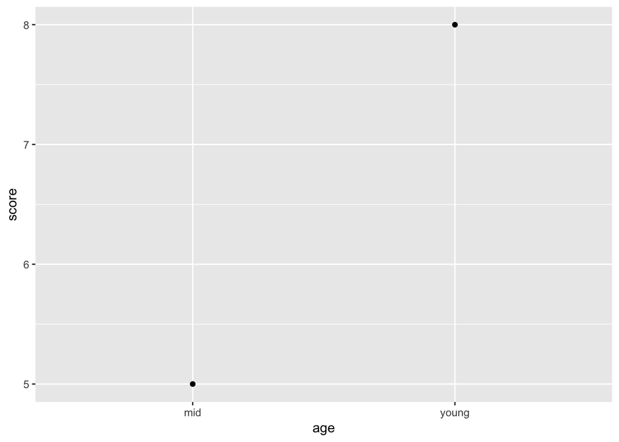

```r
young_mid = stress_data[which(stress_data$age=='young' | stress_data$age=='mid'), ]

m.young_mid = lm(score ~ age, data=young_mid)

ggplot(data=young_mid, aes(x=age, y=score)) + geom_point(stat='summary', fun.y=mean)
```

```r
anova(m.young_mid)
```

```
## Analysis of Variance Table
##
## Response: score
##           Df Sum Sq Mean Sq F value    Pr(>F)
## age        1   40.5    40.5      27 8.831e-05 ***
## Residuals 16   24.0     1.5
## ---
## Signif. codes:  0 '***' 0.001 '**' 0.01 '*' 0.05 '.' 0.1 ' ' 1
```

For the mid+old age pair, there was also a significant result to the ANOVA test. The p-value is exactly the same, 8.8e-5. The mid age group responded better than the old age group.

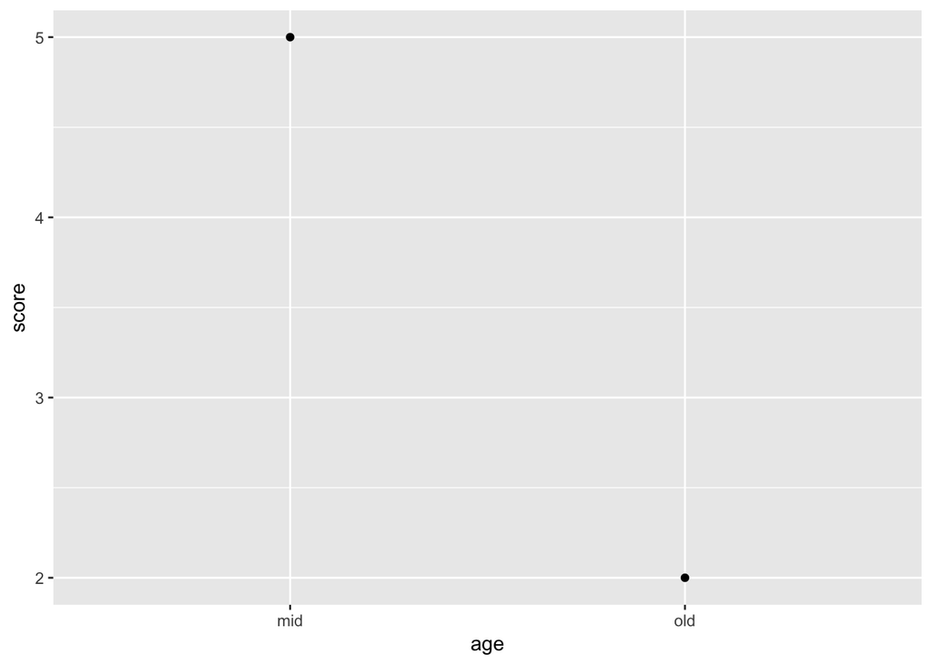

```r
mid_old = stress_data[which(stress_data$age=='mid' | stress_data$age=='old'), ]

m.mid_old = lm(score ~ age, data=mid_old)

ggplot(data=mid_old, aes(x=age, y=score)) + geom_point(stat='summary', fun.y=mean)
```

```r
anova(m.mid_old)
```

```
## Analysis of Variance Table
##
## Response: score
##           Df Sum Sq Mean Sq F value    Pr(>F)
## age        1   40.5    40.5      27 8.831e-05 ***
## Residuals 16   24.0     1.5
## ---
## Signif. codes:  0 '***' 0.001 '**' 0.01 '*' 0.05 '.' 0.1 ' ' 1
```

Finally, for the young + old age group pair, the young age group responded much better. The ANOVA produced a p-value was orders of magnitude lower (more significant), 1.6e-8.

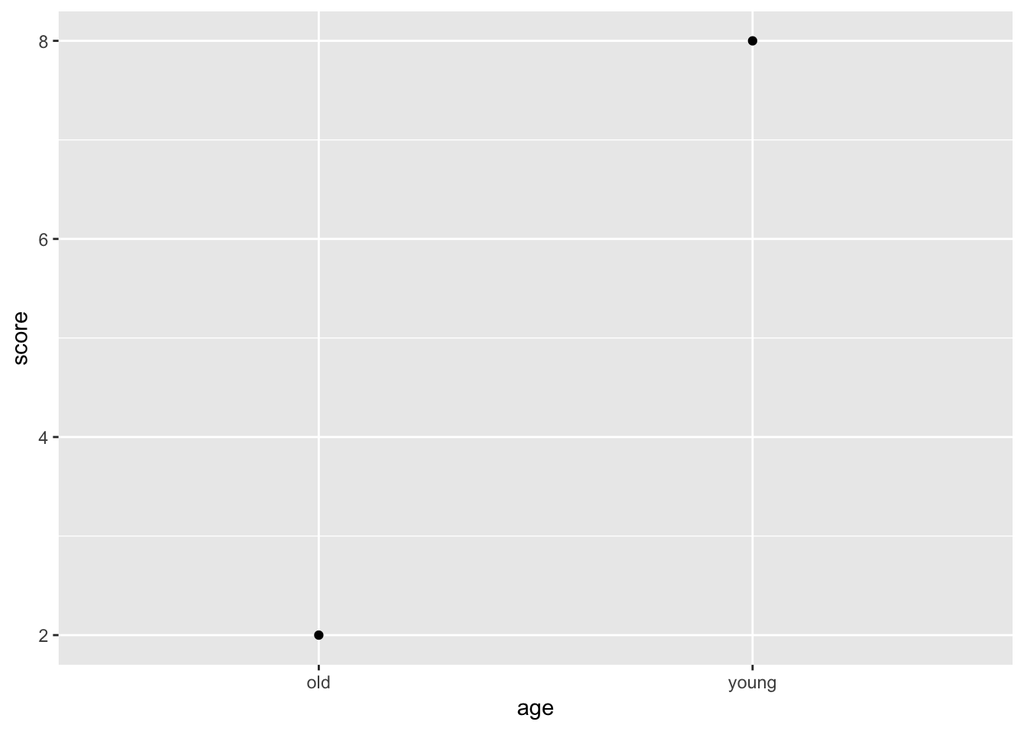

```r
young_old = stress_data[which(stress_data$age=='young' | stress_data$age=='old'), ]

m.young_old = lm(score ~ age, data=young_old)

ggplot(data=young_old, aes(x=age, y=score)) + geom_point(stat='summary', fun.y=mean)
```

```r
anova(m.young_old)
```

```
## Analysis of Variance Table
##
## Response: score
##           Df Sum Sq Mean Sq F value    Pr(>F)
## age        1    162   162.0     108 1.604e-08 ***
## Residuals 16     24     1.5
## ---
## Signif. codes:  0 '***' 0.001 '**' 0.01 '*' 0.05 '.' 0.1 ' ' 1
```